# The Nature of Negotiation

Session 1

Luis F. Gómez L.

luis.gomezl@unimilitar.edu.co

Distance Learning Faculty

8 September, 2026

# Please Read Me

- Check the message **Welcome greeting** published in the News Bulletin Board.
- Dear student please edit your profile uploading a photo where your face is clearly visible.
- The purpose of the virtual meetings is to answer questions and not to make a summary of the study material.
- This presentation is based on (Lewicki et al., 2024, Chapter 1)
- **Purpose**
  - Understand the definition of negotiation, key components of the negotiation process, major types of negotiation identified in the literature, and the relationship between negotiation and conflict management.

# The roles managers play, negotiation and conflict resolution

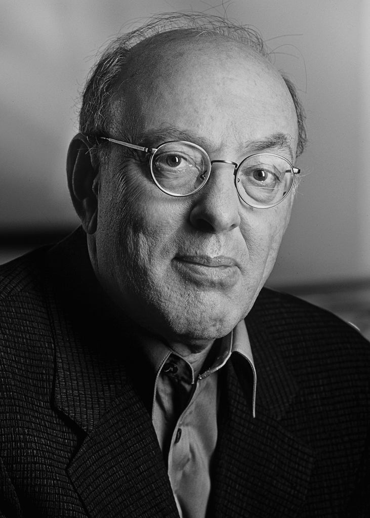

Figure 1: Henry Mintzberg (1939 - ?)

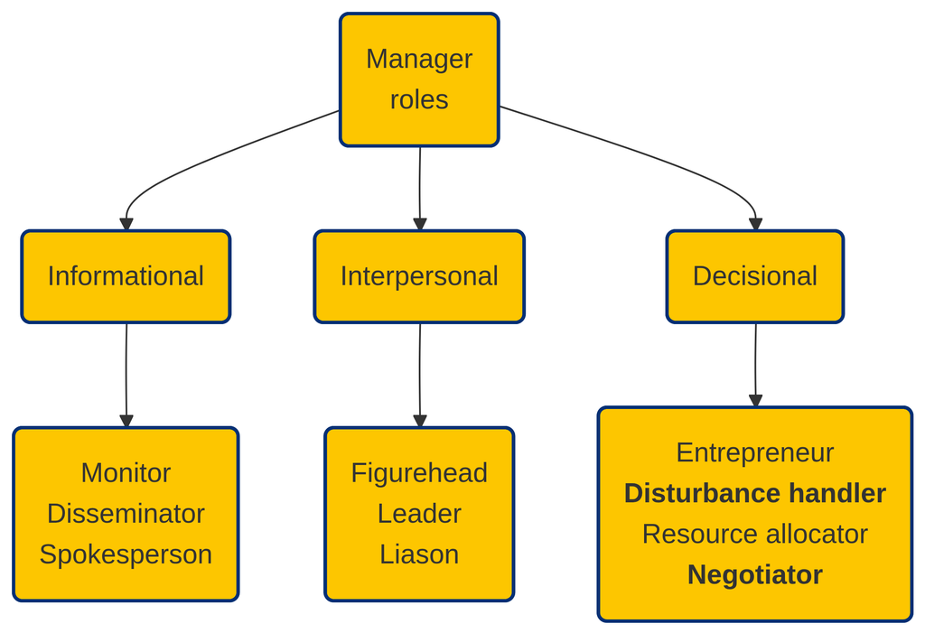

Figure 2: The roles managers play (Featured, 2019, Chapter 2, sec. 1.2)

- Management roles that apply directly to negotiation and conflict resolution (See (Mintzberg, 1989, Chapter 1))
  - **Disturbance handler**
    - Deals with conflicts or crises within the organization
  - **Negotiator**
    - Engages in negotiations both within and outside the organization

# Organizational Behavior, negotiation and conflict

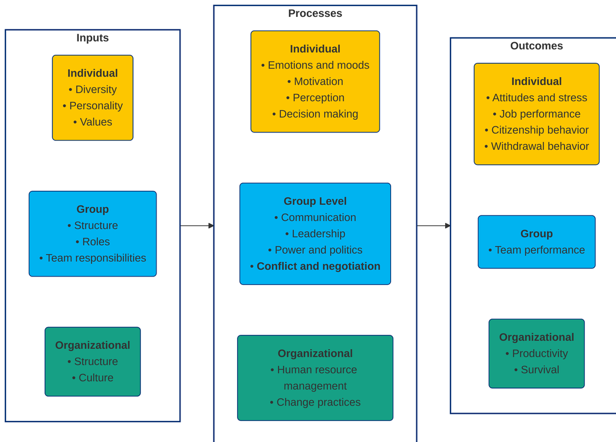

Figure 3: Basic Organizational Behavior Model (Robbins & Judge, 2024, p. 61)

# Elements of negotiation

- Definition of negotiation
  - *A form of **decision making** in which 2 or more parties talk with one another in an effort to **resolve their opposing interests**.* (Lewicki et al., 2024, Chapter 1, p. 3)
  - Also check out in the **Links of interest** the video
    - *How to negotiate properly?*[^1] (*¿Cómo Negociar Bien?*, 2018)
- 6 elements of negotiation situations are mentioned in (Lewicki et al., 2024, Chapter 1, pp. 6-9)
  - Element 1 assumes that in a negotiation there are two or more parties involved (people, groups or organizations).
  - Elements 2, 3, 4 and 5 implies that there exist **interdependence** between the parties involved[^2]:
    - Parties depend on each other to achieve their own preferred outcome (Lewicki et al., 2024, Chapter 1, p. 10)
  - Element 6 considers that there are tangible and intangible aspects:
    - **Tangibles**: aspects of which it is sought to reach an agreement within the negotiation (prices, terms of a contract, product specifications).
    - **Intangibles**: psychological motivations implicit in a negotiation (personal values and emotions of the parties involved).
- Interdependence
  - By **interdependence** we refer to a situation in which *the parties need each other in order to accomplish their objectives and hence have the potential to influence each other* (Lewicki et al., 2024, p. 10)
    - Interdependence does not mean that everyone wants or needs the same thing. (Lewicki et al., 2024, p. 11)
    - Interdependence implies that you need to work together to accomplish something. (Lewicki et al., 2024, p. 11)
- The type of interdependence that occurs between the parties affects the dynamics and the results of a negotiation:
  - **Zero-sum or distributive situation**: for one party to obtain a profit,it is necessary for another party to obtain a loss.
  - **Non-zero-sum or integrative situation**: there exists the *possibility* that all parties involved can obtain a profit without a party obtaining a loss.
- The alternatives shape the interdependence where one way to analyze the alternatives is through the concept of:
  - **Best Alternative to a Negotiated Agreement (BATAN)**[^3]
- Mutual adjustment
  - Because the parties are interdependent during a negotiation there is a process called **mutual adjustment** where the parties try to influence one another to reach an acceptable agreement.
    - At the beginning each party proposes an initial level on the tangible aspects of negotiation.
    - Then there are replicas and concessions where the **bargaining range** tends to be reduced.
    - If the **bargaining range** is reduced enough to become a point, an agreement is reached.
- Dilemmas in mutual adjustment
  - **Dilemma of honesty**: How much truth to tell the other parties? (Lewicki et al., 2024, p. 15)
    - You need to gain the trust of the other parties by telling the truth but not all the truth because you can not disclose all the information
  - **Dilemma of trust**: How much you should trust the other parties? (Lewicki et al., 2024, p. 15)
    - It depends on the reputation and past interactions with the other parties.
- Approaches and tactics
  - **Distributive Negotiation Approach**: it is conceived that there is only one winner in a particular situation and a course of action is sought to be the winner.
    - Tactic: **claim value**[^4] by doing whatever is necessary to claim the reward or gain the largest piece possible (Lewicki et al., 2024, p. 16)
- Approaches and tactics
  - **Integrative Negotiation Approach**: attempts are made to find solutions so that both parties feel satisfied and reach their goals.
    - Tactic: **create value**[^5] by finding the way for the parties involved to achieve their objectives by obtaining more resources

# Conflict

- For definitions of **conflict** please check out (Lewicki et al., 2024, p. 20)
  - 3 different definitions that are related are mentioned
- For the different levels of **conflict** please check out (Lewicki et al., 2024, pp. 20–21)
  - 4 levels of conflict are mentioned
  - We will not cover the first one in the course:
    - *Intrapersonal or intrapsychic conflict*
- For dysfunctions and functions of **conflict** please check out (Lewicki et al., 2024, pp. 21–22)
  - Dysfunctions: negative aspects of conflict
  - Functions: productive aspects of conflict

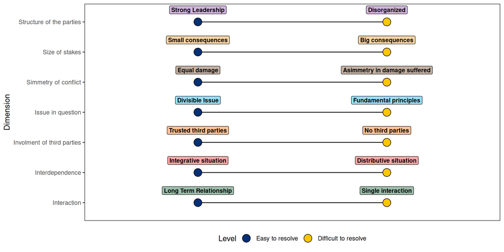

Figure 4: Conflict diagnostic model (Lewicki et al., 2024, p. 23) and (Greenhalgh, 1986, p. 47)

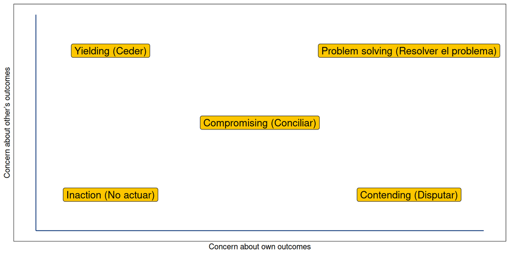

Figure 5: Dual concerns model (Lewicki et al., 2024, p. 24) and (Pruitt et al., 2004, p. 41)[^6]

# Course and book structure

- Cover in the course
  - **Negotiation Fundamentals**
    - (Lewicki et al., 2024, Chapters 1–5)
  - **Negotiation Subprocesses**
    - (Lewicki et al., 2024, Chapters 6–8)
  - **Concluding Comments**
    - (Lewicki et al., 2024, Chapter 20)
- Not cover in the course
  - **Negotiation Subprocesses**
    - (Lewicki et al., 2024, Chapter 9)
  - **Negotiation Contexts**
    - (Lewicki et al., 2024, Chapters 10–13)
  - **Individual Differences**
    - (Lewicki et al., 2024, Chapters 14–15)
  - **Negotiation across Cultures**
    - (Lewicki et al., 2024, Chapter 16)
  - **Resolving Differences**
    - (Lewicki et al., 2024, Chapters 17–19)

# Acknowledgments

- To my family that supports me
- To the taxpayers of Colombia and the [**UMNG students**](https://www.umng.edu.co/estudiante) who pay my salary
- To the [**Business Science**](https://www.business-science.io/) and [**R4DS Online Learning**](https://www.rfordatasci.com/) communities where I learn [**R**](https://www.r-project.org/about.html) and [**$\pi$-thon**](https://www.python.org/about/)
- To the [**R Core Team**](https://www.r-project.org/contributors.html), the creators of [**RStudio IDE**](https://posit.co/download/rstudio-desktop/), [**Positron**](https://positron.posit.co/), [**Quarto**](https://quarto.org/) and the authors and maintainers of the packages [**tidyverse**](https://CRAN.R-project.org/package=tidyverse), [**ggnewscale**](https://CRAN.R-project.org/package=ggnewscale) and [**tinytex**](https://CRAN.R-project.org/package=tinytex) for allowing me to access these tools without paying for a license

# References

*¿Cómo negociar bien?* (2018). https://youtu.be/CnF26cfIfQM

Featured, O. (2019). *Principles of management* (1st ed.). OpenStax. https://openstax.org/details/books/principles-management

Greenhalgh, L. (1986). SMR Forum: Managing Conflict. *Sloan Management Review*, *27*(4), 45–51.

Lewicki, R. J., Barry, B., & Saunders, D. M. (2024). *Negociación* (9th ed.). McGraw-Hill Education. https://www-ebooks7-24-com.ezproxy.umng.edu.co/?il=40562

Mintzberg, H. (1989). *Mintzberg on management: Inside our strange world of organizations*. Collier Macmillan.

Program of Negotiation. (2012). *BATNA Basics: Boost Your Power at the Bargaining Table* (p. 8). https://www.bc.edu/content/dam/files/centers/cwf/individuals/pdf/BANTABasics.pdf

Pruitt, D. G., Kim, S. H., & Rubin, J. Z. (2004). *Social conflict: Escalation, stalemate, and settlement* (3rd ed). McGraw-Hill.

Robbins, S. P., & Judge, T. A. (2024). *Organizational behavior* (19th edition, global edition). Pearson. https://www-ebooks7-24-com.ezproxy.umng.edu.co/?il=28686

Spangler, B. (2003). *Creating and Claiming Value*. Conflict Information Consortium, University of Colorado, Boulder. https://www.beyondintractability.org/essay/creating_value

## Footnotes

[^1]: The video is in spanish
[^2]: If there is no interdependence, use a decision-making process other than negotiation
[^3]: For more details check out (Program of Negotiation, 2012)
[^4]: For more details check out (Spangler, 2003)
[^5]: For more details check out (Spangler, 2003)
[^6]: *Compromising* is not considered as a viable strategy by (Pruitt et al., 2004) but (Lewicki et al., 2024) consider it